# COVID–19 : Study about mortality in the US

Statistical computation and visualization (MATH-517)

Zineb AGNAOU https://github.com/ZinebAg , Fahim BECK https://github.com/FahimBeck , Salima JAOUA https://github.com/salimajaoua , Matias JANVIN https://github.com/matiasjanvin , Seorim PARK https://github.com/seorimpark  
October 26, 2021

## Introduction

This project aims to understand the spread of COVID–19 and the reasons why the pandemic has emerged as a global matter of concern in a couple of months. At the time of the pandemic outbreak, a lack of information implied awareness in the general public. By focusing on United States, we want to show the gravity of COVID–19 and analyze different periods and turning points in the pandemic management in the US. To do so, we will focus our interest on the virus transmission, number of patients and deaths during the beginning of the pandemic and until September 2021.

### Research questions

In this investigation, we set out to answer the following questions.

1. How have the number of deaths due to COVID–19 in the United State evolved with time since the beginning of the pandemic ?
2. Next, we investigate how COVID–19 deaths are distributed across some notable risk factors. In particular, we ask ourselves : How are deaths distributed across age groups ? How are deaths distributed across the recorded location of death (meaning type of institution or private residence) ?
3. How has the mortality of COVID–19 evolved with time ?
4. How are COVID–19 cases correlated across neighbouring states ?
5. Can we predict the number of deaths in a given state and given month from the number of deaths in the k-th degree neighbour of that state ?

### Approaches

To answer the above questions, we will proceed as follows : A descriptive and visual approach where we will produce interactive plots with information on the number of deaths along different dimensions : geographically, temporally and by different risk factors. We will then proceed with the analysis of mortality rate as a function of time and based on different risk factors. Afterwards we switch to the correlation and spatial comparison studies : between two selected states, two neighbouring states or considering different levels of neighbourhoods through a separation analysis.

## Sources of information / datasets

In this project, several datasets were used to answer our questions. Each one of them refers to the same population (the US). Here are more specific descriptions.

### US deaths within categories and states

The first dataset we use is about [provisional COVID–19 deaths by place of death and age](https://data.cdc.gov/NCHS/Provisional-COVID-19-Deaths-by-Place-of-Death-and-/4va6-ph5s) from the CDC in the US. A complete description of it is available on the web page.

The variables we used in this project are : `Group`, `Year`, `Month`, `HHS Region`, `State`, `Place of Death`, `Age group`, `COVID-19 Deaths` and `Total Deaths`. What is particular here is that the sum of `COVID-19 Deaths` is not the total number of deaths in the US. Actually, we need to filter our data by `Group`, `State`, `Place of Death` and `Age Group` in order to get what we want.

A last thing we should take into account is that those numbers of deaths are not the exact number that happened during a given period. The reason is that there is always a lag in time (usually 1 to 8 weeks) between the instant when the death occurred and between when the death certificate is completed and submitted for reporting purposes.

### US deaths within categories and states

The second dataset we chose to use is about [COVID–19 cases and deaths by state over time](https://data.cdc.gov/Case-Surveillance/United-States-COVID-19-Cases-and-Deaths-by-State-o/9mfq-cb36) from the CDC in the US. This dataset contains the total number, probable and confirmed cases and deaths from COVID–19 from each state from the 22nd of January 2020 to the 15th of October 2021. The variables we used are : `submission_date`, `state`, `new_cases` and `new_deaths`. We wanted to focus on the number of new cases per day to compare them between the States. The reason why we chose a different dataset from above is because tracing the number of cases is more sensitive in catching the global trend of spread than tracing the number of new deaths. Also, the above dataset only has the number per month, whereas this has for each day which makes the comparison more accurate and precise.

### Other datasets used

The third dataset we used is about [the U.S. population in 2019 by State (extract)](https://www.census.gov/data/datasets/time-series/demo/popest/2010s-national-total.html#par_textimage_1810472256) by the Census Bureau in the U.S. This dataset is used to normalize the number of cases and deaths : since each state has a different size of population, we used the percentage of cases out of the total population of the state to compare the numbers from different states. We assumed that the population did not differ from 2019 with a confidence interval of 90% or above (the population of the states showed a global increase of less than 10% during the last 10 years).

The fourth dataset is about new cases and deaths per months. This dataset was extracted by the second dataset, by subtracting the total cases and deaths for each last days of consecutive months. This dataset was made to be used in parallel with the first dataset, and to compute the mortality rate.

## Packages

Here are some packages used in our project. Make sure they are installed before running the R Markdown file. Since the format of this Markdown is not standard, you need to install the *Distill* package. To avoid errors, install it via [Github](https://github.com/rstudio/distill) (the package is updated there) with the following command : `install.packages("devtools")` and `devtools::install_github("rstudio/distill")`.

```r
library(readr)
library(dplyr) # Useful for reading variables containing spaces
library(ggplot2)
library(reshape)
library(stringr) # Labels overlap
library(scales) # Labels value format
library(usmap)
library(Rfast)
```

## Spatial exploration of Covid deaths in the United States over time

In this subsection, we intend to visualize our data before starting different analyses. To do so, we display the number of deaths on the United States map shown in Figures (1), (2), (3) and (4). The plotted data represents the deaths per 1 million individuals, we standardise the data according to the population of each state.

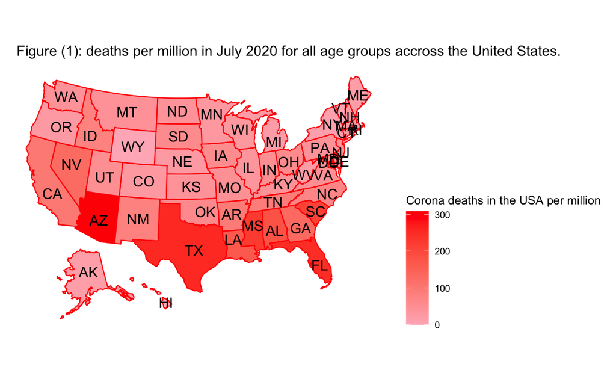

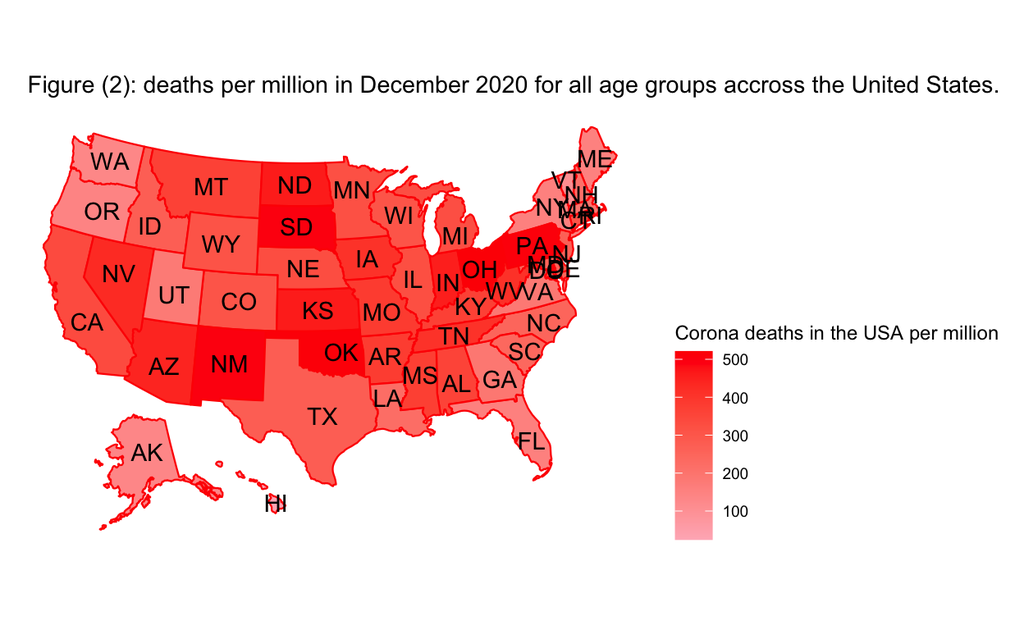

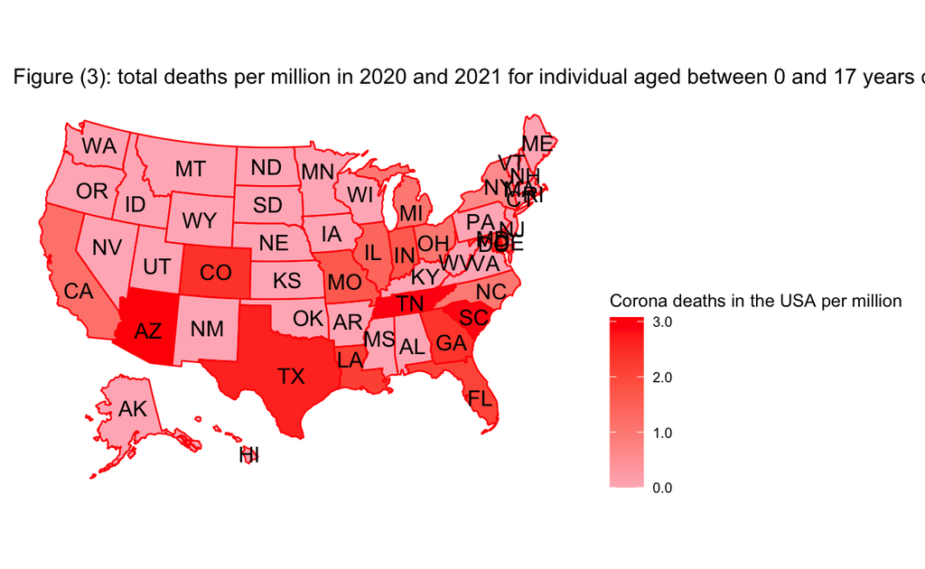

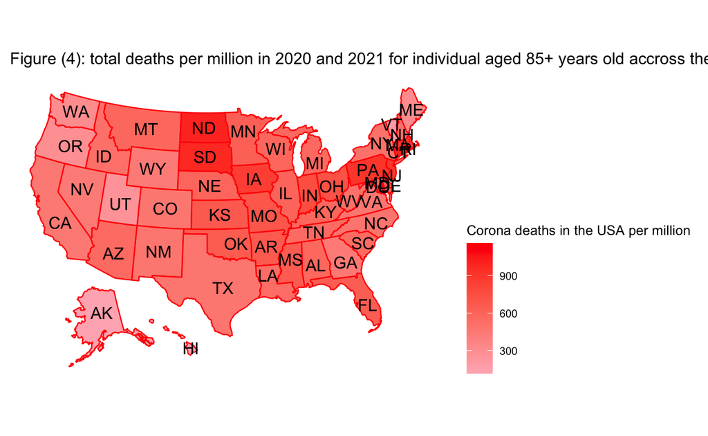

An interactive version is available under this [link](https://zinebag.shinyapps.io/InteractiveGeographicMapShiny/). You can select which map to display based on time period, age range and place of death.

## Risk factors

In this section, we will have a closer look to the risk factors of death from COVID–19. More particularly, we will first consider age and second the place where death occurred.

### Age group

Here are deaths per age group since the beginning of the pandemic.

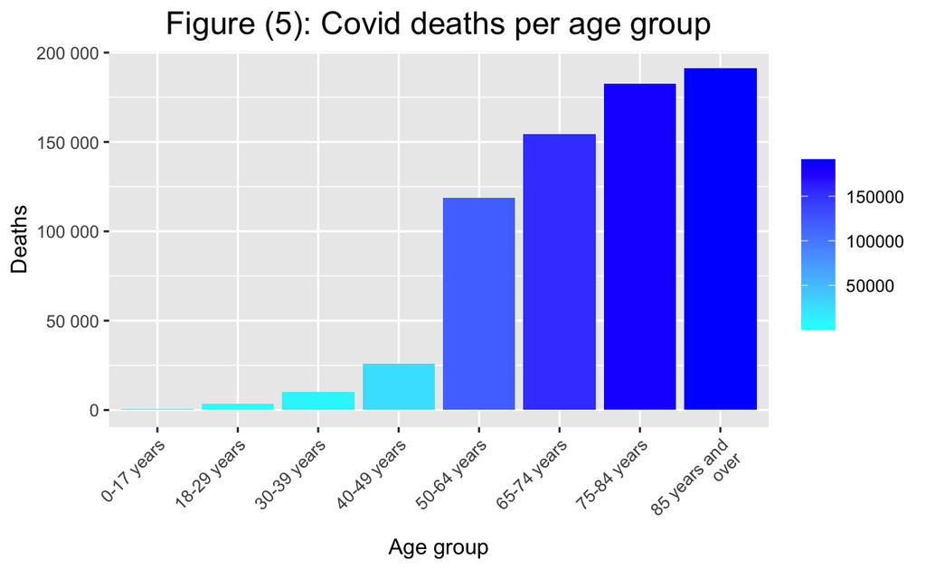

Older people are those who died the most as expected. The same barplot is available by month in an interactive web app. You can access it by clicking [here](https://fahimbeck.shinyapps.io/barplot_app/). By moving the slider, we are always able to observe a right-increase tendency on the barplots. We are also able to identify each wave.

### Place of death

Here are deaths per place of death since the beginning of the pandemic.

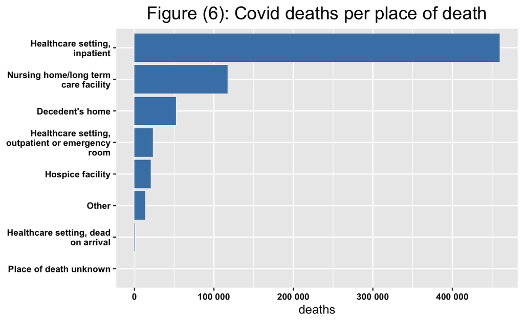

Here we can clearly see that most people were inpatients in a healthcare setting before dying. This includes ICUs and reflects our expectations. Then, people in nursing homes died also a lot as expected (older people being at risk), but much less than the previous category. The same barplot is also available by month in an interactive web app. You can access it by clicking [here](https://fahimbeck.shinyapps.io/barplot_app2/). By changing months, we are almost all the time able to observe a similar tendency : highest category being healthcare settings, and second being nursing homes. Waves can also be identified.

## Mortality rate through time

First we are going to plot the mortality rate and the incidence rate for the US through time to analyse their evolution. Secondly we are going to plot the proportion of deaths of COVID–19 called the case fatality ratio. This is important to measure the severity of COVID–19.

Let’s load the data :

```r
df <- read_csv("../Data/case_per_month.csv")
```

First, we are going to remove the column `States` and sum the new cases and respectively, the new deaths, for each month to get the number of total death in the country by month :

```r
df = df[,-c(2)]
df_us = df[,-c(4)] #delete state
df_us = df_us %>%
group_by(end_date, year, month) %>% summarise_at(vars(new_deaths_per_month,new_cases_per_month),sum) %>%
ungroup()
```

So now, we have the data for the US and not for each state. To compute the mortality rate, We are going to take the population of the country for each year. This means that we are going to neglect the fact that for each month, the population changes (so that we don’t introduce a new data set).

Now we can have a look to the data to check that our modifications worked :

```r
df_us
```

[output not shown]

Now that we have added the population of the country at each month, we are going to compute the mortality rate.

Note that the mortality rate is generally expressed by the “number of persons dead per 100,000 of the population, per period of time”, in order to allow comparisons between different populations and time periods. So, we decided to represent the mortality rate by the number of persons who died per 10,000 persons of the population.

We are ready to plot the mortality rate through time :

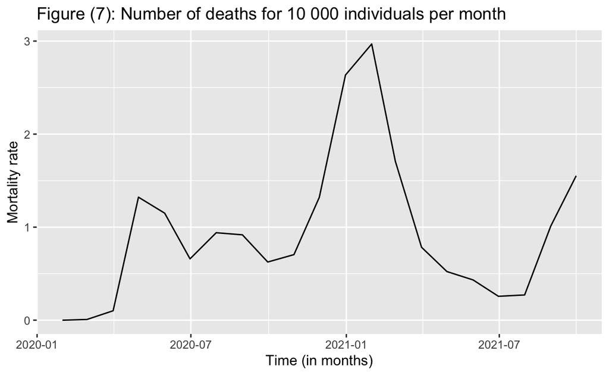

First, with the emergence of the Covid, we can see that the mortality rate increases quickly. We can note that in the beginning of 2021, there is a peak of the mortality rate which can coincide with hospital saturation. Afterwards, in June, July 2021, the rate is low. This can be explained by the weather. Now, let’s compare the mortality rate to the incidence rate. The incidence rate represents the number of persons affected by COVID–19.

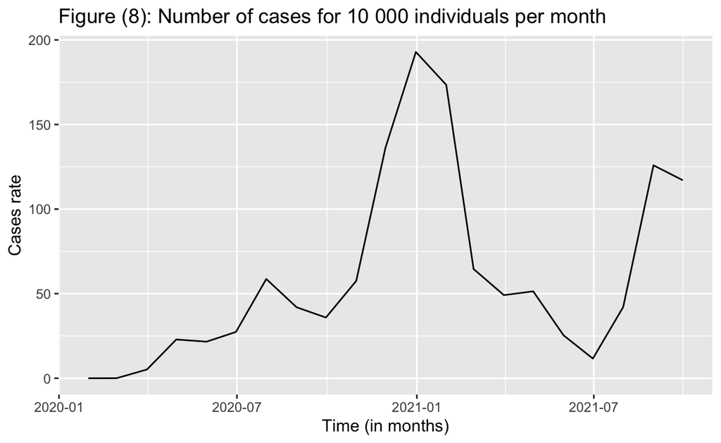

We can notice that the evolution of the incidence rate is similar to the evolution of the mortality rate. The peak at the beginning of the year 2021 is also present here. It seems coherent since the incidence rate is correlated to the number of deaths. Let’s plot both evolution at the same time to compare them.

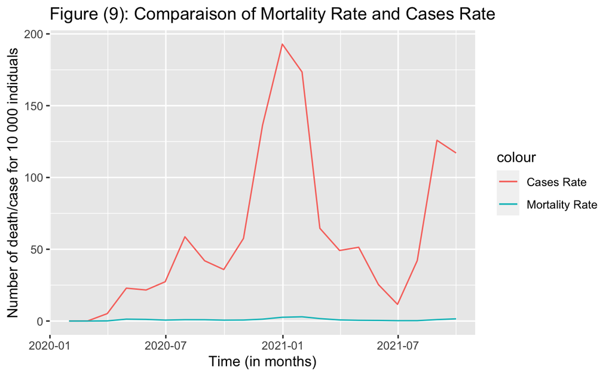

We can see that when we plot both, the mortality rate is very small compared to the incidence rate which is normal. This shows that COVID–19 has spread quickly during these two years having a lot more cases than deaths. Now, we are going to compute the proportion of deaths in the country. The problem is that we don’t know when a person who died at a certain month had COVID–19. There are no links between the data. So we are going to take an approximation of the proportion of deaths per month.

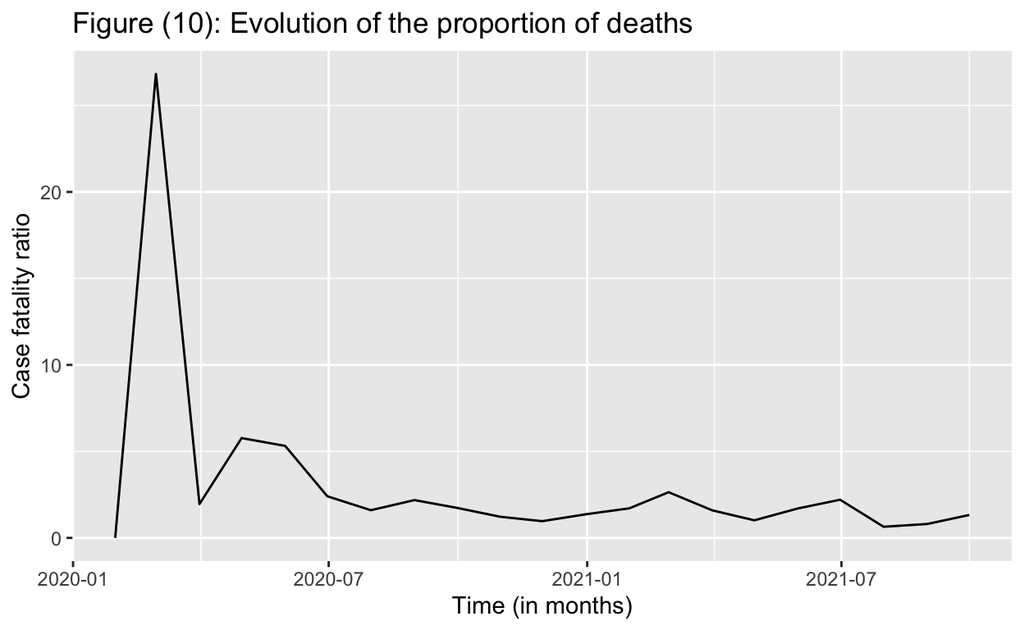

Finally, we can see that at the beginning of the spread, COVID–19 was a very mortal diseases. The peak reaches 27% : this mean that at a given time (February) more than one in four people dies of COVID–19. This information is false, in fact, the high peak can be explained by the fact that at the beginning of the pandemic, there weren’t a lot of people tested. Therefore the majority of people who got tested were very sick people and so it explains why there was a very big percentage of death. After this peak, we can see that the proportion of deaths is more or less constant as we expected. This shows that the peak present in the mortality rate is explained by the high number of confirmed cases.

## Impact of geolocation on cases and deaths from COVID–19

### Correlations depending of neighbourship

In this section, we want to validate the hypothesis that the location of the states have an impact on the number of cases and deaths from COVID–19. In order to prove it, we looked into the new number of cases and deaths from COVID–19 per day in each state, and compared between them to see if neighbouring states had a more similar trend.

Below are the plots of two example states that are not neighbouring from each other, New York and California: the percentages of new COVID–19 cases over the total state population in New York and California are plotted as a function of time.

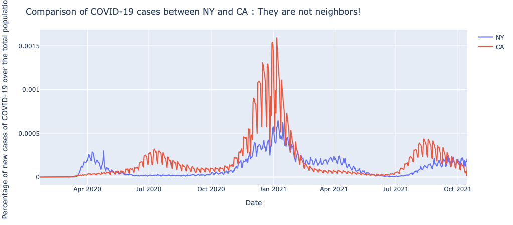

Plots CA NY

Figure(11)

Below are the plots of two example states that are neighbouring from each other, Nevada and California. We can observe that compared to the previous graph, the plots seem to look more alike.

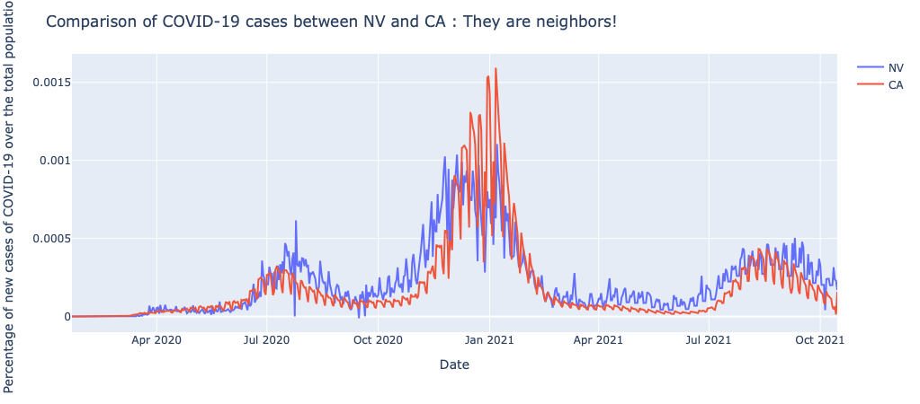

Plots CA NV

Figure(12)

To check on different pairs of states, an interactive plot was made [(Link)](https://myplotseo.herokuapp.com). We can choose the pair with the two dropdowns at the top, and the states are named with its acronyms. Also, there are two modes, Cases and Deaths at the top left, which shows the plot of new cases and new deaths from COVID–19 respectively. Once the pair is chosen, the title will reveal if the two states are actually neighbours or not.

To verify the hypothesis, we computed the Pearson correlation coefficient for each pair of States. By taking the mean of the coefficients for pairs that are neighbours and the ones for the pairs that are not neighbours, we could see a big difference (0.7575626038139122 v.s. 0.5900159155676525) We can therefore say that the trends of new COVID–19 cases are similar if the states are neighbouring from each other. We could draw a similar conclusion for the number of deaths from COVID–19, although it is not as apparent as the number of cases. (0.4804464631622195 v.s. 0.34860163565334673)

Below are the box plots of Pearson correlation coefficients between the numbers of cases from two States when they are neighbours and when they are not.

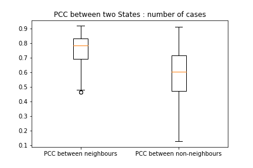

Box Plot cases

Figure(13)

We can indeed observe that the Pearson correlation coefficient is significantly higher when the two States are neighbouring than when they are not.

Below are the box plots of Pearson correlation coefficients between the numbers of deaths from two States when they are neighbours and when they are not.

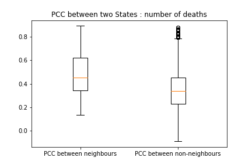

Box Plot deaths

Figure(14)

The contrast for the number of new deaths is not a apparent as the number of new cases, but we can still retrieve the result we expected.

In conclusion, the location of the State indeed has an impact on the number of cases and deaths from COVID–19. We could observe that two states have a more similar trend when they are neighbours than when they are not. There were several waves of infection in different places, and we could observe a lagging peak in cases of farther states. The reason behind this phenomenon is because people would often move from one state to another closer state. For instance, we could expect that some people living in Nevada could go to California for work, and the disease might have spread along this movement of population. However, there can also be as many people moving to big farther cities as the ones moving to nearby cities, and in that case the trend can be similar even though the states are not neighbouring to each other. For instance, New York and California both have a peak in January, although they are situated on the both extremities of the country. This phenomenon might have occurred because those two states include the two biggest city in the U.S. – Los Angeles and New York City – and the migration of population between the two cities might have been frequent at that moment.

### Predicting deaths from k-th degree neighbors

In this section, we propose and implement a linear model to predict the number of monthly COVID–19 deaths in a given state as a function of the number of deaths during the same month in a k-th degree neighbour of that state. Two states X and Y are k-th degree neighbours if at least k interstate borders must be crossed to go from one state to the other.

$$E[N_X\mid N_Y] = b_0^{(k_{XY})}+ b_1^{(k_{XY})} N_Y$$
For example, the above model can be used to predict the number of COVID–19 deaths in Massachusetts during a month given the number of deaths in Vermont during the same month, where Vermont and Massachusetts share a border and are thus 1st degree neighbours ($k=1$). The panel of figures below contains scatterplots of $N_X$ against $N_Y$ for any month and any two states that are neighbours of degree $d$. In order to find the degree of neighbourship between two states, we have treated the states as nodes on a graph, where edges correspond to borders between states. We constructed an adjacency matrix between states sharing a border, and subsequently we used the Floyd–Warshall algorithm to find the smallest number of interstate borders connecting any two states. In each panel, we have indicated the parameters $b_0$, $b_1$ and the correlation coefficient $\rho$ between $N_X$ and $N_Y$.

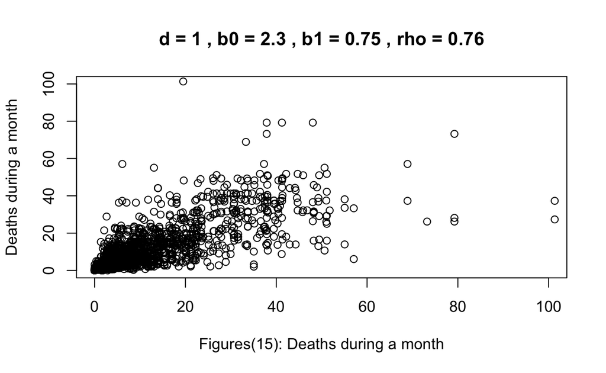

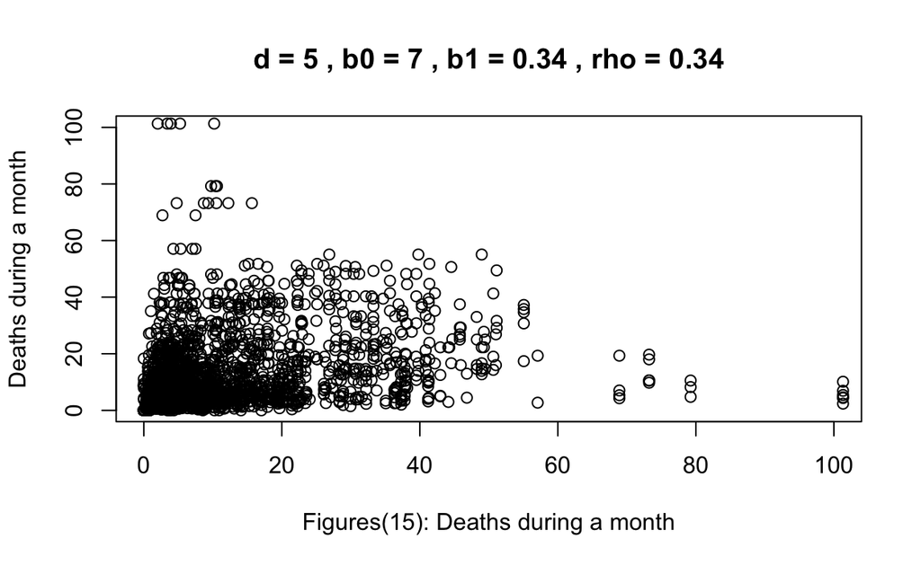

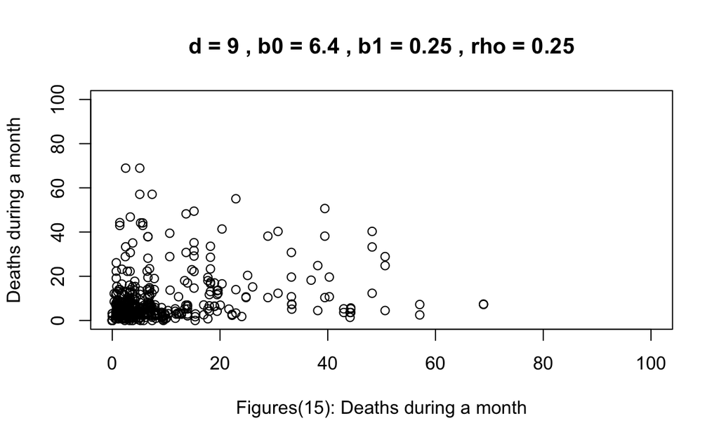

Next, we have plotted how the parameters $b_0$, $b_1$ and $\rho$ vary as a function of degree of separation $d$ below :

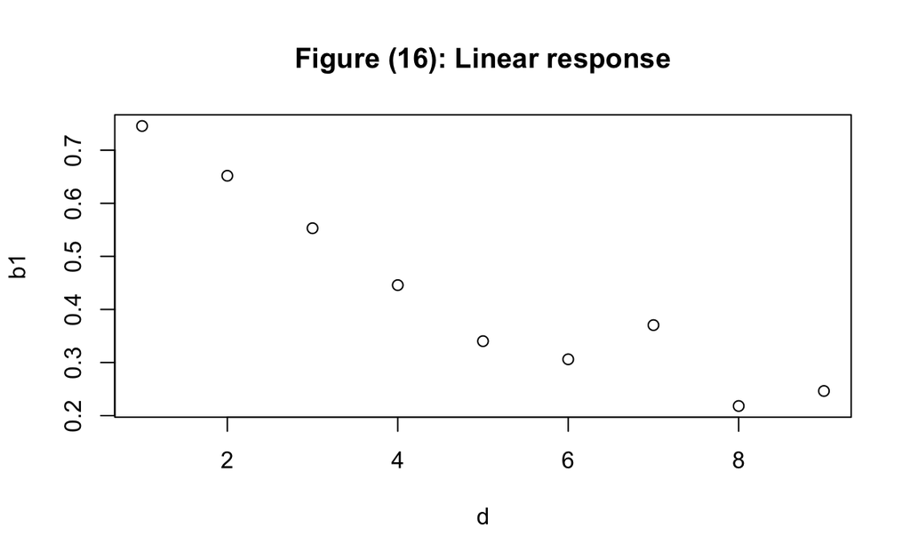

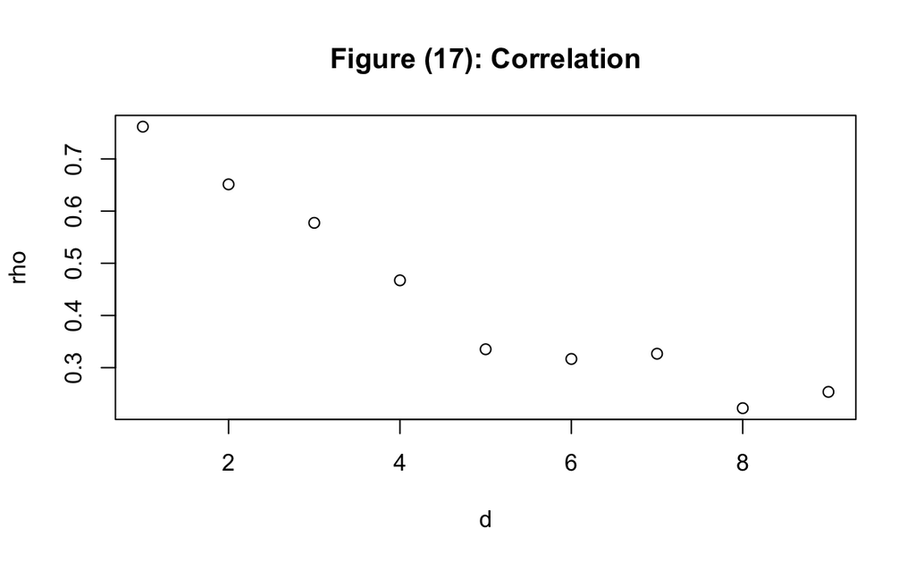

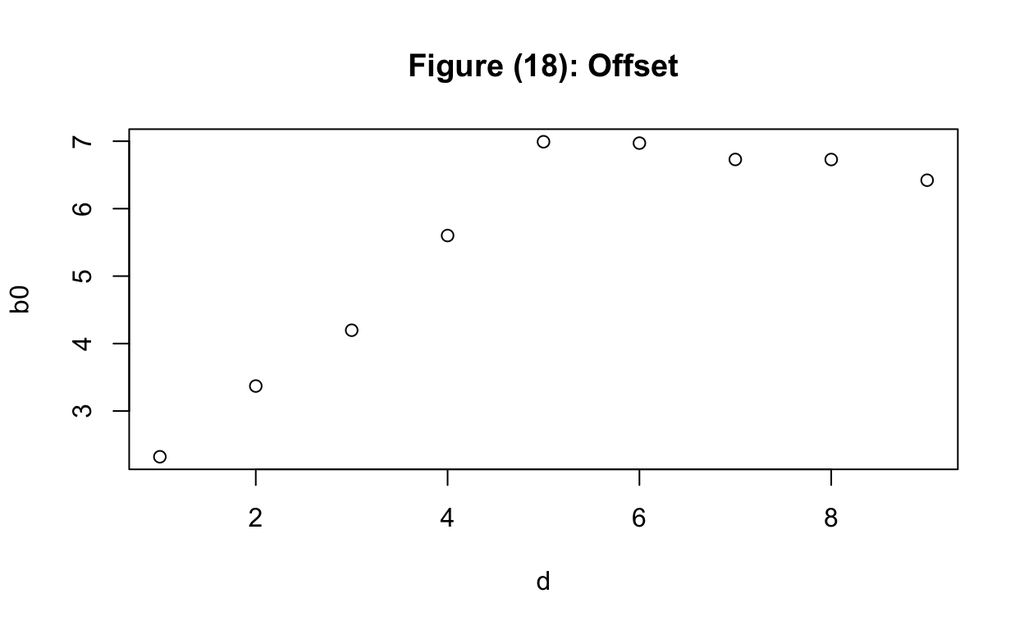

As expected, the predictive power of a neighbour decreases with increasing degree of the neighbour. We see that the variation in the number of deaths is large, and thus it is (unsurprisingly) hard to make accurate predictions of the number of deaths. The speed of attenuation of response $b_1$ with $d$ nonetheless sheds light on the spatial scale of the correlations between the number of deaths.

## Future improvements

As a further improvement and extension of the research, we suggest incorporating a forecasting model and visually displaying it in the same manner. We can also extend the following study and add more parameters such as health restrictions imposed by the government and their impact on the spread and deaths. We can further add the availability of hospitals as a parameter. With interesting and conclusive results, we can broaden our study to other countries or even other epidemics. Furthermore, another dimension to consider would be the vaccination: does it have a positive or negative effect on mortality? Finally, comorbidity can be considered.